# JSC370H1 - Assignment 1

# Part 1

```r
# Read in data
df <- read.csv("Break_and_Enter_Open_Data.csv")

# Check for import issues in the dimensions, headers, footers, variable names and types in the dataset
dim(df)
```

```
## [1] 70148    31
```

```r
head(df) # Results not shown due to space constraints
tail(df) # Results not shown due to space constraints
```

```r
# List the variables and their types
str(df) # Results not shown due to space constraints
```

```r
# Check for and display missing values
na_observations <- df %>%
  filter_all(any_vars(. %in% c('NSA')))
nrow(na_observations)
```

```
## [1] 510
```

```r
na_observations %>%
  select(HOOD_158,NEIGHBOURHOOD_158,HOOD_140,NEIGHBOURHOOD_140,LONG_WGS84,LAT_WGS84) %>%
  head()
```

```
##   HOOD_158 NEIGHBOURHOOD_158 HOOD_140 NEIGHBOURHOOD_140 LONG_WGS84 LAT_WGS84
## 1      NSA               NSA      NSA               NSA    0.00000   0.00000
## 2      NSA               NSA      NSA               NSA  -79.29727  43.82595
## 3      NSA               NSA      NSA               NSA    0.00000   0.00000
## 4      NSA               NSA      NSA               NSA    0.00000   0.00000
## 5      NSA               NSA      NSA               NSA    0.00000   0.00000
## 6      NSA               NSA      NSA               NSA    0.00000   0.00000
```

```r
# Update 'NSA' and improper coordinates in the location-related columns to 'NA'
df[df=='NSA'] <- NA
df$LONG_WGS84[df$LONG_WGS84 == 0] <- NA
df$LAT_WGS84[df$LAT_WGS84 == 0] <- NA
mean(is.na(df$LONG_WGS84))
```

```
## [1] 0.00721332
```

```r
# Checking the time variables
mean(is.na(df$OCC_DATE))
```

```
## [1] 0
```

```r
table(df$OCC_YEAR) # Results not shown due to space constraints
table(df$OCC_MONTH) # Results not shown due to space constraints
table(df$OCC_DOW) # Results not shown due to space constraints
table(df$OCC_HOUR) # Results not shown due to space constraints
```

### *Summary*

To begin exploring the dataset, I first read in the data and checked for general import issues.

# Part 2

```r
# Selecting and renaming columns, and removing NA observations
df2 <- df %>%
  select(OCC_YEAR, OCC_MONTH, OCC_DAY, OCC_HOUR, HOOD_140, LAT_WGS84, LONG_WGS84) %>%
  rename(year = OCC_YEAR, month = OCC_MONTH, day = OCC_DAY, hour = OCC_HOUR,
         hood = HOOD_140, lat = LAT_WGS84, lon = LONG_WGS84) %>%
  na.omit()

# Converting the neighborhood factor from character to numeric
df2$hood <- as.numeric(df2$hood)

# Factoring month
df2$month <- as.integer(factor(df2$month, levels = month.name))

# Checking for outliers
summary(df2$lat)
```

```
##    Min. 1st Qu.  Median    Mean 3rd Qu.    Max.
##   43.59   43.66   43.69   43.70   43.75   43.84
```

```r
summary(df2$lon)
```

```
##    Min. 1st Qu.  Median    Mean 3rd Qu.    Max.
##  -79.64  -79.45  -79.39  -79.39  -79.33  -79.12
```

```r
summary(df2$hood)
```

```
##    Min. 1st Qu.  Median    Mean 3rd Qu.    Max.
##    1.00   41.00   76.00   72.95  102.00  140.00
```

### *Summary*

I renamed these variables to make them easier to use and identify. I also removed observations with any missing values for these variables. To identify any outliers:

- I looked at the summary statistics for latitude and longitude. They appeared scaled properly, and there did not seem to be any coordinate that appeared to be outside of Toronto.
- I looked at the summary statistics for neighborhood, and there did not seem to be any value outside of the range [1, 140], where 140 is the total number of neighborhoods in the city.
- I have checked the date and time variables in the previous part, with no anomalies found.

# Part 3

```r
# Create a variable for season
df2 <- df2 %>%
  mutate(season = case_when(
    (month == 3 & day >= 21) | month == 4 | month == 5 | (month == 6 & day < 21) ~ "Spring",
    (month == 6 & day >= 21) | month == 7 | month == 8 | (month == 9 & day < 21) ~ "Summer",
    (month == 9 & day >= 21) | month == 10 | month == 11 | (month == 12 & day < 21) ~ "Autumn",
    (month == 12 & day >= 21) | month == 1 | month == 2 | (month == 3 & day < 21) ~ "Winter"
    ))

# ANOVA for the relationship between each season in any year and # of break/enters
df3 <- df2 %>%
  group_by(year, season) %>%
  mutate(count = length(season)) %>%
  ungroup() %>%
  select(season, count) %>%
  unique() %>%
  filter(count > 1000)
fit1 <- lm(count ~ season, data=df3)
summary(fit1)
```

```
##
## Call:
## lm(formula = count ~ season, data = df3)
##
## Residuals:
##    Min     1Q Median     3Q    Max
## -426.5 -177.5  -17.1  151.1  475.3
##
## Coefficients:
##              Estimate Std. Error t value Pr(>|t|)
## (Intercept)   1827.50      74.71  24.461   <2e-16 ***
## seasonSpring  -125.90     105.66  -1.192   0.2412
## seasonSummer   -45.80     105.66  -0.433   0.6673
## seasonWinter  -184.00     105.66  -1.741   0.0901 .
## ---
## Signif. codes:  0 '***' 0.001 '**' 0.01 '*' 0.05 '.' 0.1 ' ' 1
##
## Residual standard error: 236.3 on 36 degrees of freedom
## Multiple R-squared:  0.09124,    Adjusted R-squared:  0.01551
## F-statistic: 1.205 on 3 and 36 DF,  p-value: 0.3219
```

```r
anova(fit1)
```

```
## Analysis of Variance Table
##
## Response: count
##           Df  Sum Sq Mean Sq F value Pr(>F)
## season     3  201738   67246  1.2048 0.3219
## Residuals 36 2009426   55817
```

```r
# Chi-squared test on the relationship between seasons overall and # of break/enters
df4 <- df2 %>%
  group_by(season) %>%
  mutate(count = length(season)) %>%
  ungroup() %>%
  select(season, count) %>%
  unique()
matrix1 <- matrix(c(df4$count, rep(mean(df4$count), 4)), ncol=2)
matrix1
```

```
##       [,1]  [,2]
## [1,] 16485 17409
## [2,] 18300 17409
## [3,] 17828 17409
## [4,] 17023 17409
```

```r
chisq.test(matrix1)$p.value
```

```
## [1] 2.933003e-12
```

### *Summary*

First, I created a new season variable based on the month and day of the break and enter. To find if a season in any given year had the most break and enters, I calculated the number of break and enters for each season in each year. The resulting model (count ~ season) yielded R-squared coefficients of 0.09 (unadjusted) and 0.02 (adjusted), which indicate that for any given year, season likely does not relate to the number of break and enters. Also, the ANOVA for the model has a p-value of 0.3219 > 0.05, which agrees with the results of the model. Thus, for a given year, there is likely not a season with significantly more break and enters.

However, after applying the chi-squared test to find if there was significant variation between seasons across all years compared to the overall mean, I found that the test yielded a p-value of 2.933e-12 < 0.05, which indicates that when the year is not taken into account, season likely does relate to the number of break and enters. Thus, for all years combined, there is likely a season with significantly more break and enters.

To find the season with the most break and enters, I will use the exploratory plots in the next part.

# Part 4

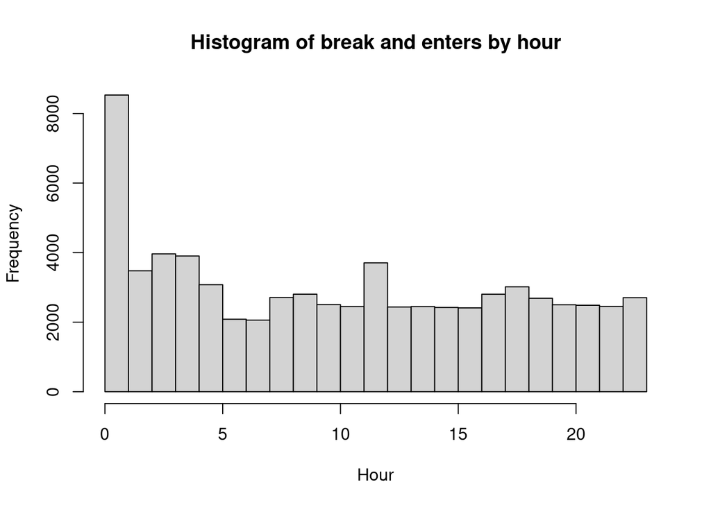

```r
# Exploratory plots of which neighbourhoods, seasons, and time of day break and enters occurred
hist(df2$hour, main="Histogram of break and enters by hour", xlab="Hour")
```

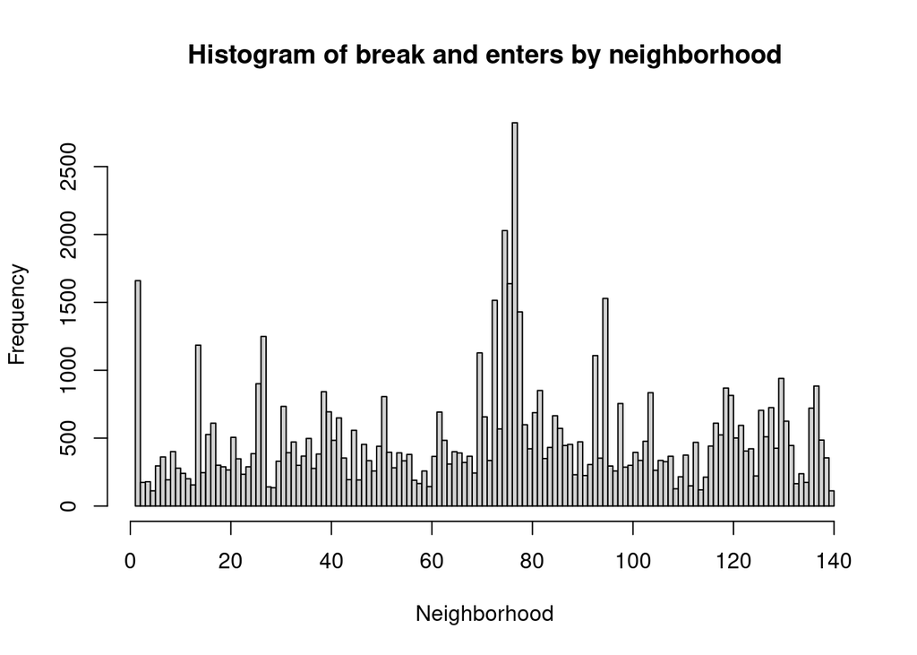

```r
hist(df2$hood, breaks=140, main="Histogram of break and enters by neighborhood", xlab="Neighborhood")
```

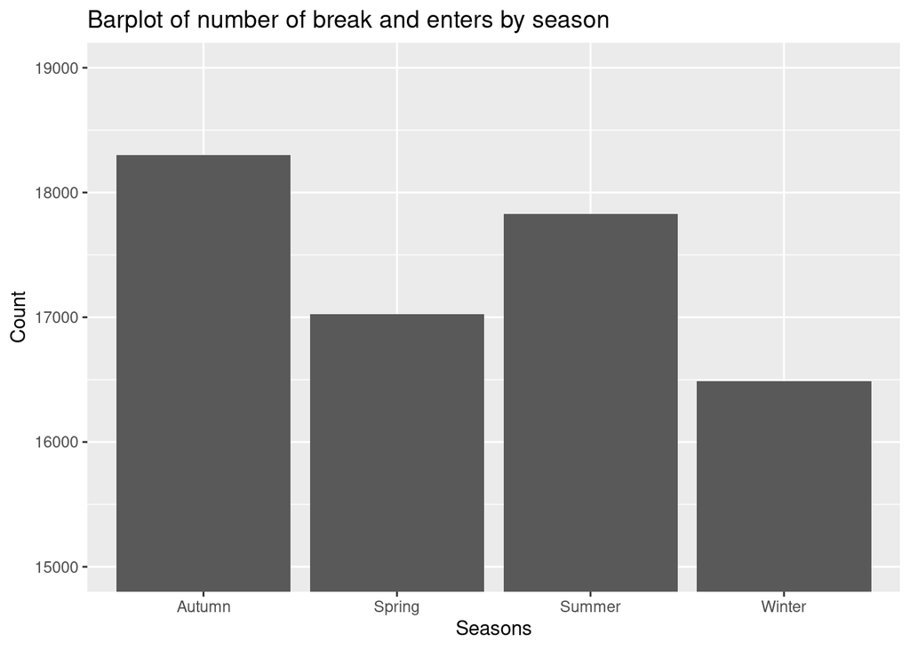

```r
ggplot(df2, aes(x=season)) +
  geom_bar() +
  coord_cartesian(ylim = c(15000, 19000)) +
  ggtitle("Barplot of number of break and enters by season") +
  xlab("Seasons") +
  ylab("Count")
```

### *Summary*

From the graphs, we can see that most break and enters happened around midnight (from 12 to 1 am), and the least happened at 5 to 7 am in the early morning. In addition, most break and enters occurred in neighborhoods 75 to 77, which correspond to the Church-Yonge corridor, Bay Street corridor, and downtown waterfront respectively. This is expected since the downtown area has a higher density of homes compared to elsewhere in Toronto. Finally, fall had the most break and enters, while winter had the least. The chi-squared test from the previous part suggested that this different is likely significant.

# Part 5

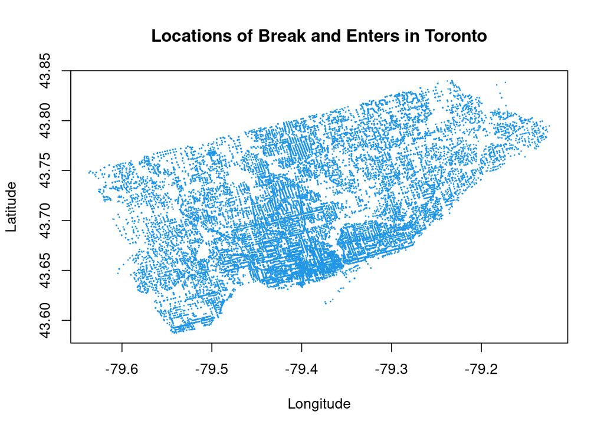

```r
# Simple plot of break/enters
plot(df2$lon, df2$lat, cex=.1, col=4, xlab="Longitude", ylab="Latitude")
title("Locations of Break and Enters in Toronto")
```

```r
# Create counts by neighborhood and get average neighborhood coordinates
leaflet_data <- df2 %>%
  group_by(hood) %>%
  mutate(n_hood = length(hood), avg_hood_lat = mean(lat), avg_hood_lon = mean(lon)) %>%
  ungroup() %>%
  select(n_hood, avg_hood_lat, avg_hood_lon) %>%
  unique()

# Create leaflet map
pal <- colorNumeric(palette = c("lightskyblue", "mediumblue"),
                    domain = leaflet_data$n_hood)

leaflet() %>%
  addProviderTiles(providers$CartoDB.Positron) %>%
  addCircleMarkers(
    leaflet_data$avg_hood_lon, leaflet_data$avg_hood_lat,
    color = pal(leaflet_data$n_hood),
    radius = 2.5
  ) %>%
  addLabelOnlyMarkers(
    leaflet_data$avg_hood_lon, leaflet_data$avg_hood_lat,
    label = as.character(leaflet_data$n_hood),
    labelOptions = labelOptions(
      noHide = TRUE, textOnly = TRUE, direction = "top",
      style = list(
        "font-size" = "13px",
        "color" = "black")
    )
  ) %>%
  addLegend("bottomleft", pal = pal, values = leaflet_data$n_hood,
    title = "# of break/enters</br>per neighborhood",
    opacity = .75
  )
```

[interactive chart not shown]

### *Summary*

The first map shows that most break and enters occurred near the waterfront in the downtown area, which is consistent with the results in the previous part. Similarly, the leaflet map shows that the highest counts of break and enters occur in the downtown area.

Overall, most break and enters reported in Toronto occurred during fall in the downtown area.